# Stats C116 HW 4 Charles Liu (304804942)

Charles Liu

November 26, 2019

# Load Necessary Packages:

```r
library(MASS)
library(rstanarm)
library(rstan)
library(arm)
library(foreign)
library(sure)
```

# Loading necessary data:

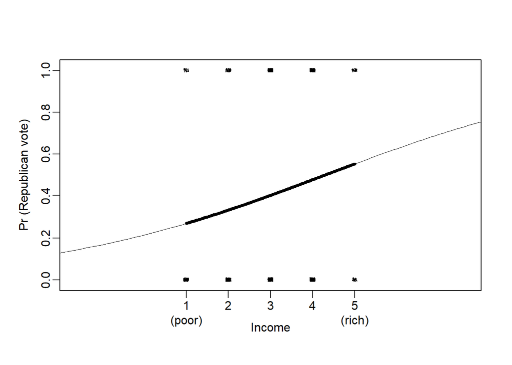

```r
nes <- read.dta("http://www.stat.ucla.edu/~handcock/216/datasets/nes/nes5200_processed_voters_realideo.dta",convert.factors=FALSE)
attach(nes)
yr <- 1992
ok <- year==yr & presvote<3
vote <- presvote[ok] - 1
income <- nes$income[ok]
invlogit <- function (x) {1/(1+exp(-x))}
fit.1 <- glm(vote ~ income, family=binomial(link="logit"))
curve (invlogit(fit.1$coef[1] + fit.1$coef[2]*x), 1, 5, ylim=c(-.01,1.01),
       xlim=c(-2,8), xaxt="n", xaxs="i", mgp=c(2,.5,0),
       ylab="Pr (Republican vote)", xlab="Income", lwd=4)
curve (invlogit(fit.1$coef[1] + fit.1$coef[2]*x), -2, 8, lwd=.5, add=T)
axis (1, 1:5, mgp=c(2,.5,0))
mtext ("(poor)", 1, 1.5, at=1, adj=.5)
mtext ("(rich)", 1, 1.5, at=5, adj=.5)
points (jitter(income, .3), jitter(vote, .04), pch=20, cex=.1)
```

```r
# Note no conversion into factors
brdata <- read.dta( "http://www.stat.ucla.edu/~handcock/216/examples/nes/nes5200_processed_voters_realideo.dta", convert.factors=FALSE)
Nes.red <- brdata[brdata$presvote < 3,] # Remove third-party candidates
Nes.red$presvote <- ifelse(Nes.red$presvote==2, 1, 0) # recode as Republican or not
Nes.red
```

[output not shown]

[output cut: 14503 more lines]

# Q1a: (changed variable for: Age –> Female)

```r
fita <- glm(presvote ~ female + black + income + real_ideo + income:real_ideo,
           family = binomial(link = "logit"), data = Nes.red, subset=(year==1992))
summary(fita)
```

```
##
## Call:
## glm(formula = presvote ~ female + black + income + real_ideo +
##     income:real_ideo, family = binomial(link = "logit"), data = Nes.red,
##     subset = (year == 1992))
##
## Deviance Residuals:
##     Min       1Q   Median       3Q      Max
## -2.6937  -0.6557  -0.1922   0.7775   2.7722
##
## Coefficients:
##                  Estimate Std. Error z value Pr(>|z|)
## (Intercept)      -2.37003    0.96950  -2.445 0.014502 *
## female           -0.01808    0.16834  -0.107 0.914466
## black            -3.41082    0.56162  -6.073 1.25e-09 ***
## income           -0.75282    0.30882  -2.438 0.014780 *
## real_ideo         0.36890    0.21618   1.706 0.087922 .
## income:real_ideo  0.22858    0.06933   3.297 0.000977 ***
## ---
## Signif. codes:  0 '***' 0.001 '**' 0.01 '*' 0.05 '.' 0.1 ' ' 1
##
## (Dispersion parameter for binomial family taken to be 1)
##
##     Null deviance: 1327.8  on 969  degrees of freedom
## Residual deviance:  878.1  on 964  degrees of freedom
##   (26293 observations deleted due to missingness)
## AIC: 890.1
##
## Number of Fisher Scoring iterations: 6
```

```r
fitb <- stan_glm(presvote ~ female + black + income + real_ideo + income:real_ideo,
            family = binomial(link = "logit"), data = Nes.red, subset=(year==1992))
summary(fitb)
```

```
##
## Model Info:
##  function:     stan_glm
##  family:       binomial [logit]
##  formula:      presvote ~ female + black + income + real_ideo + income:real_ideo
##  algorithm:    sampling
##  sample:       4000 (posterior sample size)
##  priors:       see help('prior_summary')
##  observations: 970
##  predictors:   6
##
## Estimates:
##                    mean   sd   10%   50%   90%
## (Intercept)      -2.5    1.0 -3.8  -2.5  -1.3
## female            0.0    0.2 -0.2   0.0   0.2
## black            -3.4    0.5 -4.1  -3.3  -2.7
## income           -0.7    0.3 -1.1  -0.7  -0.3
## real_ideo         0.4    0.2  0.1   0.4   0.7
## income:real_ideo  0.2    0.1  0.1   0.2   0.3
##
## Fit Diagnostics:
##            mean   sd   10%   50%   90%
## mean_PPD 0.4    0.0  0.4   0.4   0.5
##
## The mean_ppd is the sample average posterior predictive distribution of the outcome variable (for details see help('summary.stanreg')).
##
## MCMC diagnostics
##                  mcse Rhat n_eff
## (Intercept)      0.0  1.0  1761
## female           0.0  1.0  2808
## black            0.0  1.0  2757
## income           0.0  1.0  1666
## real_ideo        0.0  1.0  1758
## income:real_ideo 0.0  1.0  1654
## mean_PPD         0.0  1.0  4203
## log-posterior    0.0  1.0  1359
##
## For each parameter, mcse is Monte Carlo standard error, n_eff is a crude measure of effective sample size, and Rhat is the potential scale reduction factor on split chains (at convergence Rhat=1).
```

# Q1b:

```r
fit1 <- stan_glm(presvote ~ female + black + income + real_ideo + income:real_ideo,
                 family = binomial(link = "logit"), data = Nes.red, subset=(year==1992),
                 prior = normal(location = 0,scale = 100,autoscale = FALSE))
summary(fit1)
```

```
##
## Model Info:
##  function:     stan_glm
##  family:       binomial [logit]
##  formula:      presvote ~ female + black + income + real_ideo + income:real_ideo
##  algorithm:    sampling
##  sample:       4000 (posterior sample size)
##  priors:       see help('prior_summary')
##  observations: 970
##  predictors:   6
##
## Estimates:
##                    mean   sd   10%   50%   90%
## (Intercept)      -2.4    1.0 -3.6  -2.4  -1.2
## female            0.0    0.2 -0.2   0.0   0.2
## black            -3.6    0.6 -4.3  -3.5  -2.8
## income           -0.8    0.3 -1.2  -0.7  -0.4
## real_ideo         0.4    0.2  0.1   0.4   0.7
## income:real_ideo  0.2    0.1  0.1   0.2   0.3
##
## Fit Diagnostics:
##            mean   sd   10%   50%   90%
## mean_PPD 0.4    0.0  0.4   0.4   0.5
##
## The mean_ppd is the sample average posterior predictive distribution of the outcome variable (for details see help('summary.stanreg')).
##
## MCMC diagnostics
##                  mcse Rhat n_eff
## (Intercept)      0.0  1.0  1780
## female           0.0  1.0  4466
## black            0.0  1.0  1674
## income           0.0  1.0  1702
## real_ideo        0.0  1.0  1821
## income:real_ideo 0.0  1.0  1725
## mean_PPD         0.0  1.0  2844
## log-posterior    0.0  1.0  1393
##
## For each parameter, mcse is Monte Carlo standard error, n_eff is a crude measure of effective sample size, and Rhat is the potential scale reduction factor on split chains (at convergence Rhat=1).
```

## EXPLANATION for Q1b:

The results are essentially similar after the introduction of the flat prior.

# Q2:

```r
fit <- glm(presvote ~ female + black + income,
           family = binomial(link = "logit"), data = Nes.red, subset=(year==1964))
summary(fit)
```

```
##
## Call:
## glm(formula = presvote ~ female + black + income, family = binomial(link = "logit"),
##     data = Nes.red, subset = (year == 1964))
##
## Deviance Residuals:
##     Min       1Q   Median       3Q      Max
## -1.0918  -0.9412  -0.8422   1.3490   1.6406
##
## Coefficients:
##              Estimate Std. Error z value Pr(>|z|)
## (Intercept)  -1.15513    0.21592  -5.350 8.81e-08 ***
## female       -0.07918    0.13611  -0.582  0.56072
## black       -16.82942  420.51043  -0.040  0.96808
## income        0.19010    0.05839   3.256  0.00113 **
## ---
## Signif. codes:  0 '***' 0.001 '**' 0.01 '*' 0.05 '.' 0.1 ' ' 1
##
## (Dispersion parameter for binomial family taken to be 1)
##
##     Null deviance: 1337.7  on 1061  degrees of freedom
## Residual deviance: 1254.0  on 1058  degrees of freedom
##   (25997 observations deleted due to missingness)
## AIC: 1262
##
## Number of Fisher Scoring iterations: 16
```

```r
nrow(nes)
```

```
## [1] 41498
```

```r
yr1964 <- nes[nes$year == 1964 & nes$presvote < 3 & nes$year,]
table(yr1964$black)
```

```
##
##    0    1
## 1008   92
```

## EXPLANATION for Q2:

We see that the sample size for blacks (1964) have a much lower amount of samples compared to the overall sample size. The sample error is the inverse of the sample size. Therefore, a smaller sample size indicated a larger error for blacks (1964).

```r
table(yr1964$presvote, yr1964$black)
```

```
##
##       0   1
##   1 651  92
##   2 357   0
```

We can also see that there are blacks (1964) who only voted for one candidate. Their responses are not a good estimate for this GLM.

```r
fitc <- stan_glm(presvote ~ female + black + income,
           family = binomial(link = "logit"), data = Nes.red, subset=(year==1964))
summary(fitc)
```

```
##
## Model Info:
##  function:     stan_glm
##  family:       binomial [logit]
##  formula:      presvote ~ female + black + income
##  algorithm:    sampling
##  sample:       4000 (posterior sample size)
##  priors:       see help('prior_summary')
##  observations: 1062
##  predictors:   4
##
## Estimates:
##               mean   sd   10%   50%   90%
## (Intercept) -1.2    0.2 -1.4  -1.2  -0.9
## female      -0.1    0.1 -0.3  -0.1   0.1
## black       -4.6    1.2 -6.2  -4.5  -3.2
## income       0.2    0.1  0.1   0.2   0.3
##
## Fit Diagnostics:
##            mean   sd   10%   50%   90%
## mean_PPD 0.3    0.0  0.3   0.3   0.3
##
## The mean_ppd is the sample average posterior predictive distribution of the outcome variable (for details see help('summary.stanreg')).
##
## MCMC diagnostics
##               mcse Rhat n_eff
## (Intercept)   0.0  1.0  2965
## female        0.0  1.0  3178
## black         0.0  1.0  1423
## income        0.0  1.0  3094
## mean_PPD      0.0  1.0  3970
## log-posterior 0.0  1.0  1546
##
## For each parameter, mcse is Monte Carlo standard error, n_eff is a crude measure of effective sample size, and Rhat is the potential scale reduction factor on split chains (at convergence Rhat=1).
```

Rather than using Maximum Likelihood Estimation (MLE) to check the standard deviation, we use the MCMC (Bayesian model) method to apply and have more accurate values.The Bayesian model adds priors (independent by default) on the coefficients of the GLM.

# Q3:

```r
fitb <- stan_glm(presvote ~ female + black + income + real_ideo + income:real_ideo,
                 family = binomial(link = "logit"), data = Nes.red, subset=(year==1992))
summary(fitb)
```

```
##
## Model Info:
##  function:     stan_glm
##  family:       binomial [logit]
##  formula:      presvote ~ female + black + income + real_ideo + income:real_ideo
##  algorithm:    sampling
##  sample:       4000 (posterior sample size)
##  priors:       see help('prior_summary')
##  observations: 970
##  predictors:   6
##
## Estimates:
##                    mean   sd   10%   50%   90%
## (Intercept)      -2.5    0.9 -3.7  -2.5  -1.3
## female            0.0    0.2 -0.2   0.0   0.2
## black            -3.4    0.5 -4.0  -3.3  -2.7
## income           -0.7    0.3 -1.1  -0.7  -0.3
## real_ideo         0.4    0.2  0.1   0.4   0.7
## income:real_ideo  0.2    0.1  0.1   0.2   0.3
##
## Fit Diagnostics:
##            mean   sd   10%   50%   90%
## mean_PPD 0.4    0.0  0.4   0.4   0.5
##
## The mean_ppd is the sample average posterior predictive distribution of the outcome variable (for details see help('summary.stanreg')).
##
## MCMC diagnostics
##                  mcse Rhat n_eff
## (Intercept)      0.0  1.0  1659
## female           0.0  1.0  3551
## black            0.0  1.0  2966
## income           0.0  1.0  1612
## real_ideo        0.0  1.0  1617
## income:real_ideo 0.0  1.0  1589
## mean_PPD         0.0  1.0  4281
## log-posterior    0.0  1.0  1795
##
## For each parameter, mcse is Monte Carlo standard error, n_eff is a crude measure of effective sample size, and Rhat is the potential scale reduction factor on split chains (at convergence Rhat=1).
```

```r
fitd <- stan_glm(presvote ~ female + black + income + real_ideo + income:real_ideo,
                 family = binomial(link = "probit"), data = Nes.red, subset=(year==1992))
summary(fitd)
```

```
##
## Model Info:
##  function:     stan_glm
##  family:       binomial [probit]
##  formula:      presvote ~ female + black + income + real_ideo + income:real_ideo
##  algorithm:    sampling
##  sample:       4000 (posterior sample size)
##  priors:       see help('prior_summary')
##  observations: 970
##  predictors:   6
##
## Estimates:
##                    mean   sd   10%   50%   90%
## (Intercept)      -1.6    0.5 -2.3  -1.6  -0.9
## female            0.0    0.1 -0.1   0.0   0.1
## black            -1.9    0.3 -2.3  -1.9  -1.6
## income           -0.4    0.2 -0.6  -0.4  -0.2
## real_ideo         0.3    0.1  0.1   0.3   0.4
## income:real_ideo  0.1    0.0  0.1   0.1   0.2
##
## Fit Diagnostics:
##            mean   sd   10%   50%   90%
## mean_PPD 0.4    0.0  0.4   0.4   0.5
##
## The mean_ppd is the sample average posterior predictive distribution of the outcome variable (for details see help('summary.stanreg')).
##
## MCMC diagnostics
##                  mcse Rhat n_eff
## (Intercept)      0.0  1.0  1619
## female           0.0  1.0  3410
## black            0.0  1.0  3287
## income           0.0  1.0  1633
## real_ideo        0.0  1.0  1594
## income:real_ideo 0.0  1.0  1591
## mean_PPD         0.0  1.0  4011
## log-posterior    0.0  1.0  1496
##
## For each parameter, mcse is Monte Carlo standard error, n_eff is a crude measure of effective sample size, and Rhat is the potential scale reduction factor on split chains (at convergence Rhat=1).
```

## EXPLANATION for Q3:

The results are essentially similar. The logit model uses something called the cumulative distribution function of the logistic distribution. The probit model uses something called the cumulative distribution function of the standard normal distribution to define f(…). Both functions will take any number and rescale it to fall between 0 and 1.

# Q4a:

```r
nesdf <- data.frame(partyid7, real_ideo, dem_therm)
fit2 <- polr(factor(partyid7) ~ real_ideo + dem_therm, Hess = TRUE, method = "logistic",
             data = nesdf)
summary(fit2)
```

```
## Call:
## polr(formula = factor(partyid7) ~ real_ideo + dem_therm, data = nesdf,
##     Hess = TRUE, method = "logistic")
##
## Coefficients:
##              Value Std. Error t value
## real_ideo  0.41510  0.0157875   26.29
## dem_therm -0.03912  0.0008646  -45.24
##
## Intercepts:
##     Value    Std. Error t value
## 1|2  -2.4563   0.0983   -24.9854
## 2|3  -1.1798   0.0958   -12.3166
## 3|4  -0.4951   0.0951    -5.2061
## 4|5  -0.0191   0.0949    -0.2012
## 5|6   0.7422   0.0952     7.7982
## 6|7   1.9190   0.0972    19.7425
##
## Residual Deviance: 30740.09
## AIC: 30756.09
## (32336 observations deleted due to missingness)
```

# Q4b

We can use the t-value to test them for the t-test. The thing is that there is no default significance to test it against. Then, we see the usual regression output coefficient table including the value of each coefficient, standard errors, and t value, which is the ratio of the coefficient to the standard error. What it is comparing is the responses to the variables to give the values, std. error, and t value.

# Q4c:

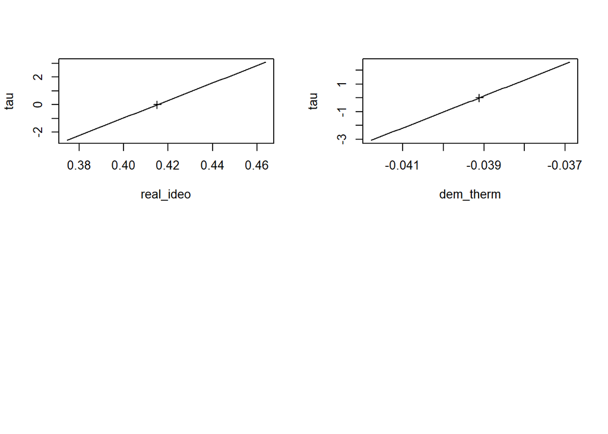

```r
plot(profile(fit2))
```

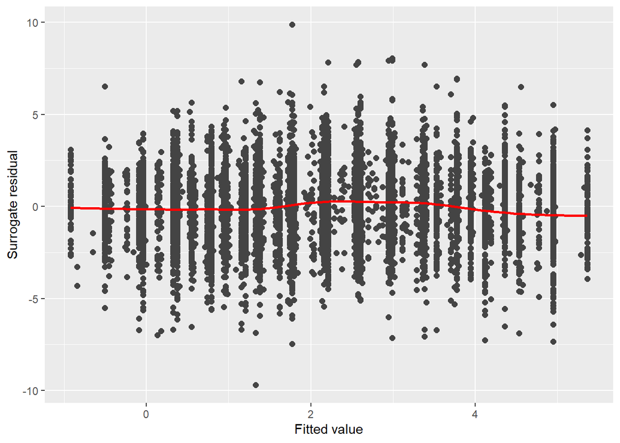

```r
autoplot.polr(fit2, what = "fitted")
```

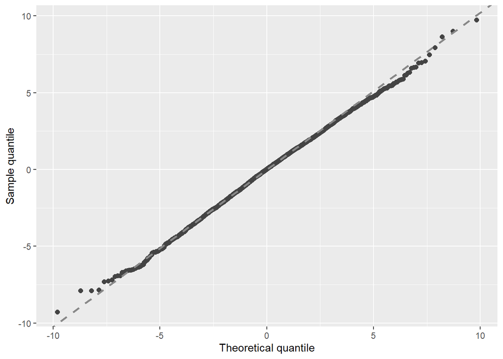

```r
autoplot.polr(fit2, what = "qq")
```

From what the plot shows, the “fitted” shows the residuals are randomly fitted. The “qq” shows that our variables follow the same, if not similar, distribition.